# Reproducible Research - Project 1

## Introduction

This project concerns a data set containing information about the number of steps a person takes throughout the day.

```r
activity <- read.csv("activity.csv")
```

## Distribution of Total Steps per Day

The following histogram, generated by this chunk of code, displays the distribution of total steps per day, for the days that do not contain missing data. It also returns the mean and median total number of steps.

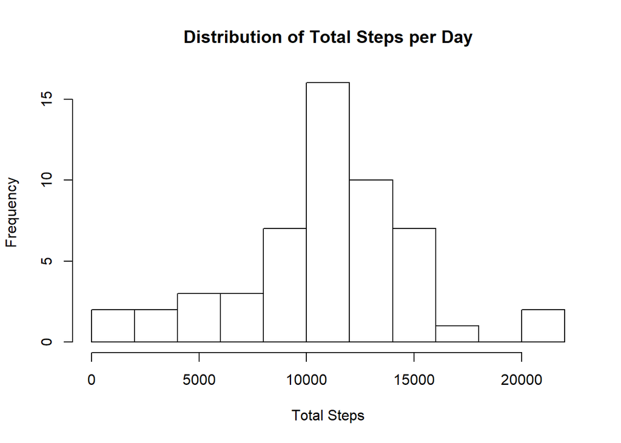

```
##     mean   median
## 10766.19 10765.00
```

```r
dateHist <- function(a) {
    datelist <- as.vector(unique(a$date))
    daytotals <- c()
    i <- 1
    for (d in datelist) {
        daytotals[i] <- sum(a[a$date==d,]$steps)
        i <- i + 1
    }
    hist(daytotals,xlab="Total Steps",
         main="Distribution of Total Steps per Day",breaks=10)

    x <- c(mean(daytotals,na.rm=TRUE),median(daytotals,na.rm=TRUE))
    names(x) <- c("mean","median")
    x
}

dateHist(activity)
```

## Daily Activity Pattern

The dataset tracks the number of steps over a set of 5-minute intervals throughout each day. The following plot displays the way the activity pattern changes throughout the day. Specifically, it plots the average number of steps taken in each 5-minute interval.

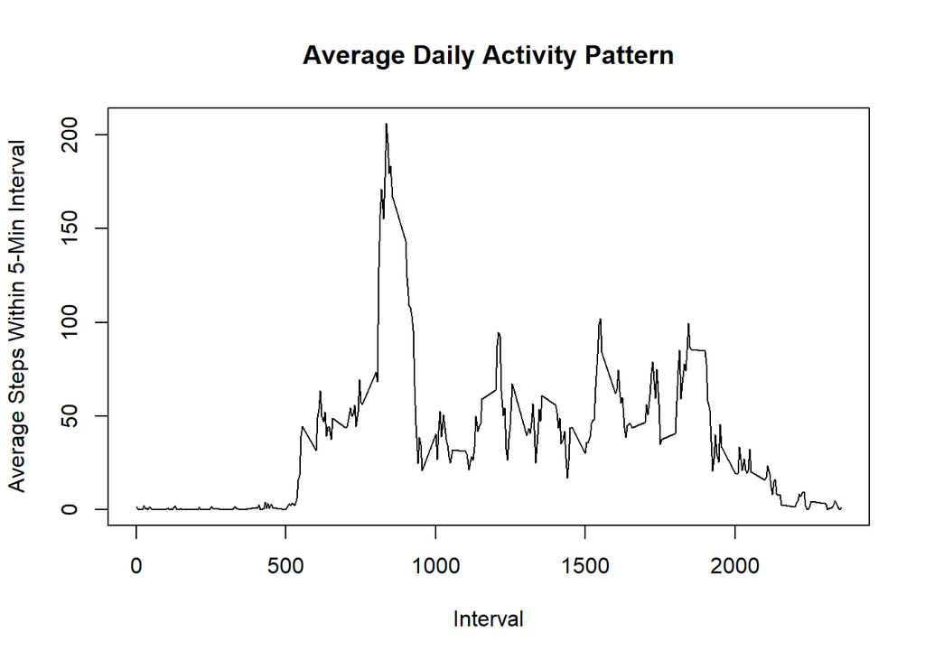

```r
xlist <- as.vector(unique(activity$interval))
xmeans <- c()
j <- 1
for (x in xlist) {
    xmeans[j] <- mean(activity[activity$interval==x,]$steps,na.rm=TRUE)
    j <- j + 1
}
plot(xlist,xmeans,type="l",main="Average Daily Activity Pattern",xlab="Interval",
     ylab="Average Steps Within 5-Min Interval")
```

We can also calculate which interval contains the highest average daily number of steps:

```r
xlist[match(max(xmeans),xmeans)]
```

```
## [1] 835
```

## Missing Values

```r
sum(is.na(activity$steps))
```

```
## [1] 2304
```

There are 2304 missing values in this data set. In fact, there are 8 days which consist entirely of NA values, 288 each, and the rest of the days have no NA values. We can use a simple method to replace these NA values: For each value at a particular interval, we shall simply use the interval mean daily steps that we calculated earlier. For coherence, we’ll also round each mean to the nearest integer number of steps.

```r
activity2 <- activity
for (k in 1:17568) {
    if (is.na(activity2[k,]$steps)) {
        y <- activity2[k,]$interval
        activity2[k,]$steps <- round(xmeans[match(y,xlist)])
    }
}
```

Now, let’s take a look at the resulting distribution of steps per day.

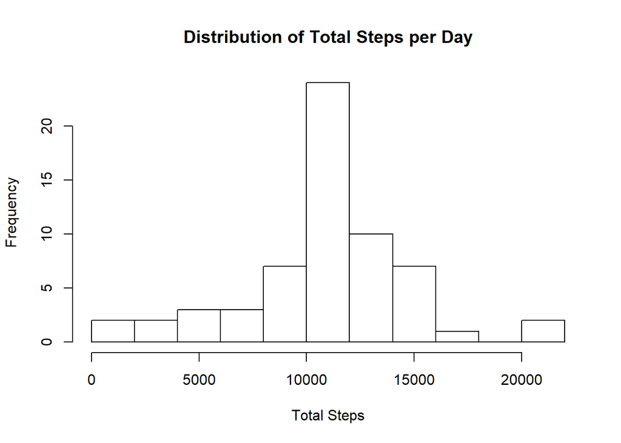

```
##     mean   median
## 10765.64 10762.00
```

```r
dateHist(activity2)
```

Most of the histogram has remained the same, but one of the bins has a noticable spike. This is unsurprising: every one of the eight “NA” days was replaced with the exact same set of values. All eight instance of this average of this set of values, making up an “average” day, fell into the same bin, causing the spike.

The overall mean daily steps per day has decreased slightly due to our rounding operation. Due to the addition of the new data, the median has shifted as well, very slightly downwards.

## Comparison of Weekdays and Weekends

Finally, let us create a panel plot highlighting the difference between the daily activity pattern on weekdays versus weekends.

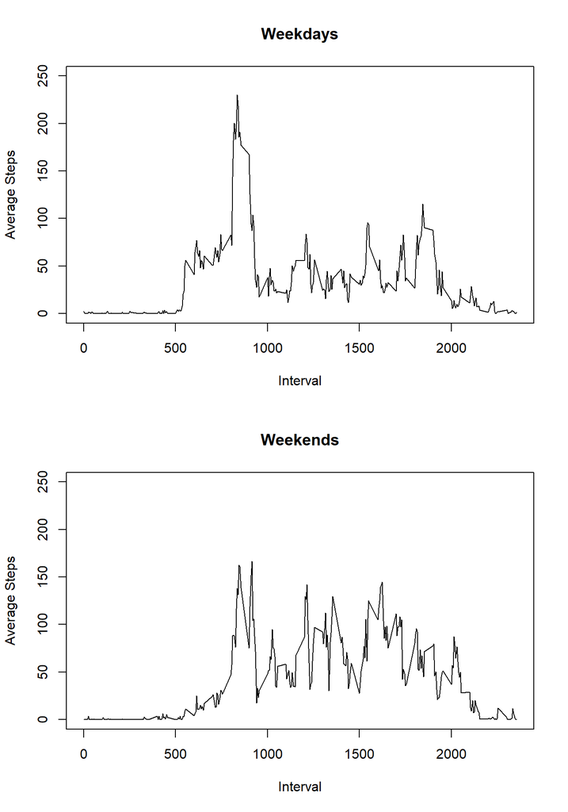

```r
# add weekday/weekend factor
activity2$date <- as.POSIXct(activity2$date)
for (m in 1:17568) {
    if (weekdays(activity2$date[m]) %in% c("Saturday","Sunday")) {
        activity2[m,4] <- "weekend"
    } else {
        activity2[m,4] <- "weekday"
    }

}
names(activity2)[4] <- "type"

# replicate average interval steps, separating weekdays and weekends
splitmeans <- matrix(nrow=288,ncol=2)
n <- 1
for (x in xlist) {
    splitmeans[n,1] <- mean(activity2[activity2$interval==x & activity2$type=="weekday",]$steps)
    splitmeans[n,2] <- mean(activity2[activity2$interval==x & activity2$type=="weekend",]$steps)
    n <- n + 1
}

# plot the partitioned data
par(mfrow=c(2,1))
plot(xlist,splitmeans[,1],type="l",main="Weekdays",xlab="Interval",
     ylab="Average Steps",ylim = c(0,250))
plot(xlist,splitmeans[,2],type="l",main="Weekends",xlab="Interval",
     ylab="Average Steps", ylim = c(0,250))
```

The distributions are somewhat different. On the weekends, there is not as much activity in the first 1000 or so interval units. However, there is an increase in activity later in the day.